# 3D’omics | Micro-scale spatial metagenomics (MSSM)

https://doi.org/10.1101/2025.09.30.679663

*Carlotta Pietroni[^1]*

*Jorge Langa[^2]*

*Iñaki Odriozola Larrañaga[^3]*

*Amalia Bogri[^4]*

*Antton Alberdi[^5]*

*2026-10-30*

# Chapter 1 Introduction

This webbook provides all the code used in the analyses for the study “Micro-scale spatial metagenomics: revealing high-resolution spatial biogeography of gut microbiomes”. The project 3D’omics (http://www.3domics.eu) was Funded by European Union’s Horizon 2020 Research and Innovation programme.

## 1.1 Prepare the R environment

### 1.1.1 Environment

To reproduce all the analyses locally, clone this repository in your computer using:

```
RStudio > New Project > Version Control > Git
```

And indicating the following git repository:

> https://github.com/3d-omics/MSSM.git

Once the R project has been created, follow the instructions and code chunks shown in this webbook.

### 1.1.2 Libraries

To keep installs out of your global R library, run this in the project before loading packages:

```r
dir.create("r-lib", showWarnings = FALSE)
.libPaths(c(file.path(getwd(), "r-lib"), .libPaths()))
```

The packages below are required. Most install from CRAN or GitHub.

```r
#install.packages('BiocManager', dependencies = TRUE)
# BiocManager::install(c("phyloseq", "ggtreeExtra","ggtree", "ALDEx2", "ComplexHeatmap"))

if (!require("pacman")) install.packages("pacman")
# If the package is not installed, installs from CRAN
pacman::p_load( tidyverse, jsonlite, ape, ggtree, phytools, ggnewscale, ggtreeExtra, ggpubr, broom, reshape2, zCompositions, ALDEx2, car, DHARMa, sjPlot, ggeffects, ggh4x, vegan, ggfortify, ggrepel, microbiome, ggforce, patchwork, grid, pheatmap, janitor, spdep, adespatial, adegraphics, ade4, magick, permuco, rmarkdown, purrr, PerformanceAnalytics, bookdown, htmlwidgets, webshot, kableExtra, hexbin, ComplexHeatmap, rstatix, circlize, scales)
#If the package is not installed, installs from GitHub
pacman::p_load_gh("anttonalberdi/hilldiv2", "anttonalberdi/distillR", "wilkelab/cowplot")

select <- dplyr::select
recode <- dplyr::recode
#install.packages("colorspace")
```

## 1.2 Define Plotting Settings

### 1.2.1 Color Schemes

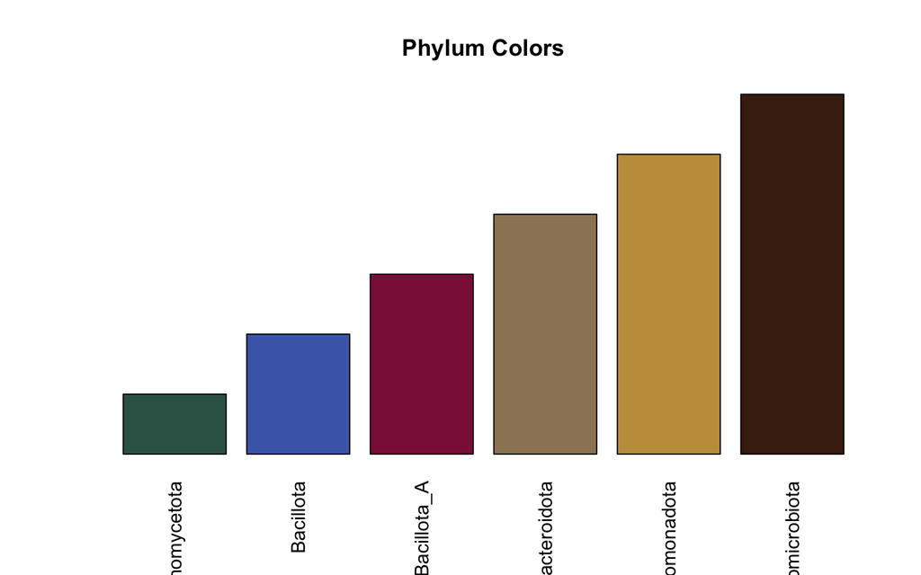

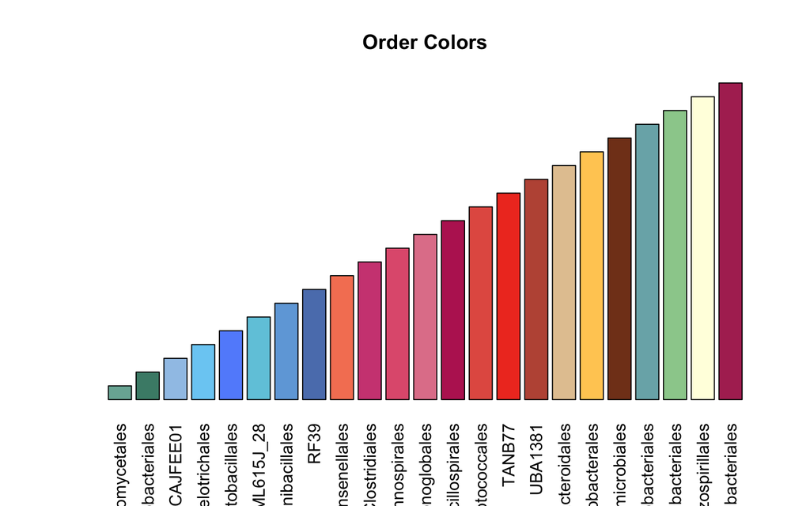

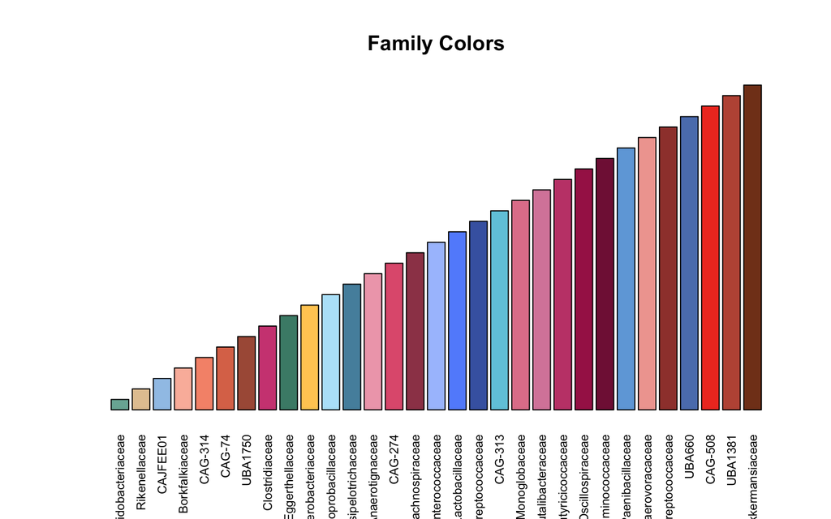

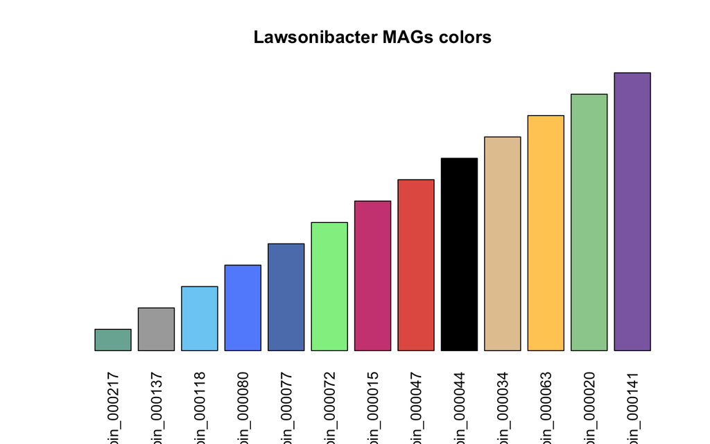

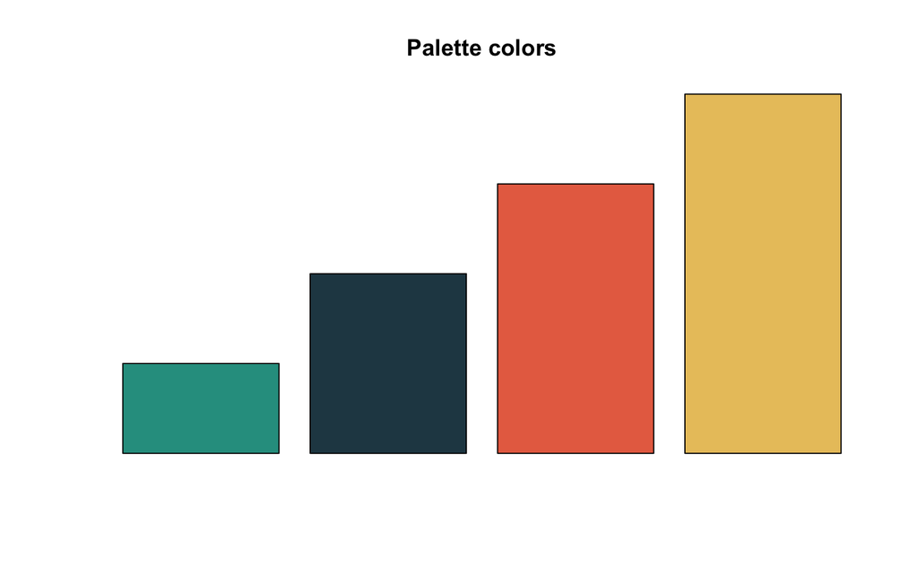

### 1.2.2 Plotting Theme

[figure not shown]

## 1.3 Load Functions

The functions defined below are used throughout other sections of this analysis and must be loaded before running those parts.

```r
source("resources/scripts/MSSM_functions.R")
source("resources/scripts/JEC_1743_sm_apps5.R")
```

[^1]: University of Copenhagen, carlotta.pietroni@sund.ku.dk
[^2]: University of the Basque Country, jorgeeliseo.langa@ehu.eus
[^3]: University of Copenhagen, inaki.larranaga@sund.ku.dk
[^4]: University of Copenhagen, amalia.bogri@sund.ku.dk
[^5]: University of Copenhagen, antton.alberdi@sund.ku.dk